# Phase 3 — Base Population PK Model

One-compartment oral, first-order absorption (nlmixr2 / rxode2)

Author

Pramod BR

Published

June 28, 2026

## 1 Objectives

Having characterised the data (Phase 1) and computed model-free exposure metrics (Phase 2), we now fit a **structural population PK model**: a one-compartment model with first-order oral absorption. This phase establishes the model skeleton and the typical (population-average) parameters; between-subject variability and covariates are layered on in Phases 4–5.

## 2 From tidy data to NONMEM events

Estimation engines treat every row as an **event** — either a dose or an observation. `build_nonmem_data()` inserts one dosing row per subject at time 0 and keeps the concentration rows as observations.

```r
dat <- build_nonmem_data()
dat |>
  dplyr::filter(ID == 1) |>
  kbl(caption = "Subject 1 as an event dataset (dose row first, then observations)",
      digits = 2) |>
  kable_styling(bootstrap_options = c("striped", "hover", "condensed"),
                full_width = FALSE)
```

Subject 1 as an event dataset (dose row first, then observations)

| ID | TIME | DV | AMT | EVID | CMT | MDV | WT |
| --- | --- | --- | --- | --- | --- | --- | --- |
| 1 | 0.00 | NA | 319.99 | 1 | 1 | 1 | 79.6 |
| 1 | 0.00 | 0.74 | 0.00 | 0 | 2 | 0 | 79.6 |
| 1 | 0.25 | 2.84 | 0.00 | 0 | 2 | 0 | 79.6 |
| 1 | 0.57 | 6.57 | 0.00 | 0 | 2 | 0 | 79.6 |
| 1 | 1.12 | 10.50 | 0.00 | 0 | 2 | 0 | 79.6 |
| 1 | 2.02 | 9.66 | 0.00 | 0 | 2 | 0 | 79.6 |
| 1 | 3.82 | 8.58 | 0.00 | 0 | 2 | 0 | 79.6 |
| 1 | 5.10 | 8.36 | 0.00 | 0 | 2 | 0 | 79.6 |
| 1 | 7.03 | 7.47 | 0.00 | 0 | 2 | 0 | 79.6 |
| 1 | 9.05 | 6.89 | 0.00 | 0 | 2 | 0 | 79.6 |
| 1 | 12.12 | 5.94 | 0.00 | 0 | 2 | 0 | 79.6 |
| 1 | 24.37 | 3.28 | 0.00 | 0 | 2 | 0 | 79.6 |

Column meanings: **EVID** = 1 marks the dose (with **AMT** in mg) and 0 marks an observation (with **DV**, the concentration); **MDV** = 1 means “no measured DV on this row” (true for dose rows); **CMT** routes the dose to the depot (1) and the observation to the central compartment (2).

## 3 The structural model

The model is a function with an `ini` block (starting values) and a `model` block (the structure). Fixed effects are estimated on the **log scale**, so the back-transformed CL, V, and Ka are always positive. Initial values are seeded from the Phase 2 NCA, which puts the optimiser close to the solution from the start.

The fitted model’s structure is shown as equations in the next section.

The two `d/dt(...)` lines are the compartment mass-balance equations; `cp = center/v` is the predicted concentration; and `cp ~ add(add.sd) + prop(prop.sd)` specifies a **combined additive + proportional** residual error model. The base model carries between-subject variability on **CL only** (`eta.cl`) — variability on V and Ka is added in Phase 4.

## 4 Fitting the model (FOCEi)

`fit_base_model()` estimates the parameters by **FOCEi** (First-Order Conditional Estimation with interaction), the workhorse algorithm of population PK.

```r
fit <- fit_base_model(dat)
```

$$\begin{align*}
{ka} & = \exp\left({tka}\right) \\
{cl} & = \exp\left({tcl}+{eta.cl}\right) \\
{v} & = \exp\left({tv}\right) \\
\frac{d \: depot}{dt} & = -{ka} {\times} {depot} \\
\frac{d \: center}{dt} & = {ka} {\times} {depot}-\left(\frac{{cl}}{{v}}\right) {\times} {center} \\
{cp} & = \frac{{center}}{{v}} \\
{cp} & \sim add({add.sd})+prop({prop.sd})
\end{align*}$$

## 5 Parameter estimates

```r
base_param_table(fit) |>
  kbl(caption = "Base model fixed-effect estimates (back-transformed)",
      digits = 3) |>
  kable_styling(bootstrap_options = c("striped", "hover", "condensed"),
                full_width = FALSE)
```

Base model fixed-effect estimates (back-transformed)

| Parameter | Est. | SE | %RSE | Back-transformed(95%CI) | BSV(CV%) | Shrink(SD)% |
| --- | --- | --- | --- | --- | --- | --- |
| tka | 0.677 | 0.265 | 39.1 | 1.97 (1.17, 3.31) |  |  |
| tcl | 1.04 | 0.0721 | 6.96 | 2.82 (2.45, 3.25) | 23.5 | 7.91%< |
| tv | 3.53 | 0.0454 | 1.29 | 34 (31.1, 37.2) |  |  |
| add.sd | 0.225 |  |  | 0.225 |  |  |
| prop.sd | 0.259 |  |  | 0.259 |  |  |

### 5.1 Sanity check vs NCA

The population model and the model-free NCA should tell a consistent story:

| Parameter | NCA (geo. mean, Phase 2) | Base model (typical) |
| --- | --- | --- |
| CL (L/h) | ~2.74 | 2.82 |
| V (L) | ~31.6 | 34 |
| Ka (1/h) | ~1.5 (from Tmax) | 1.97 |

Close agreement is the key validation that the structural model and dataset are correct — the two independent methods converge on the same physiology.

## 6 Quick predicted-vs-observed check

Full diagnostics (GOF, VPC, CWRES) come in Phase 6; here we just confirm the fit is sensible — points should scatter around the line of identity.

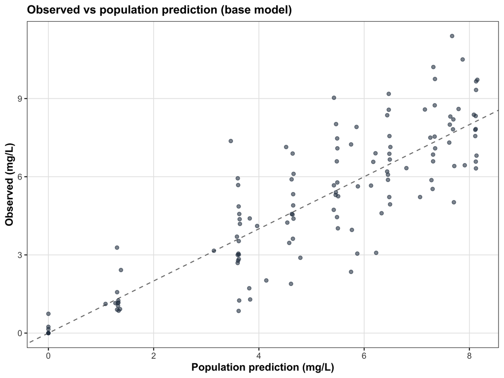

```r
fitdf <- as.data.frame(fit)

p <- ggplot2::ggplot(fitdf, ggplot2::aes(PRED, DV)) +
  ggplot2::geom_abline(slope = 1, intercept = 0, linetype = "dashed", colour = "grey50") +
  ggplot2::geom_point(alpha = 0.6, colour = "#2C3E50") +
  ggplot2::labs(x = "Population prediction (mg/L)", y = "Observed (mg/L)",
                title = "Observed vs population prediction (base model)")
p
```

```r
save_fig(p, "03_base_obs_vs_pred")
```

## 7 Key takeaways

- The data were re-expressed as a NONMEM **event** dataset (dose + observation rows).
- A **one-compartment oral** model with first-order absorption was fitted by **FOCEi**.
- Typical estimates (**CL ≈ 2.82 L/h**, **V ≈ 34 L**, **Ka ≈ 1.97 /h**) agree with the NCA — the structural model holds.
- The base model includes IIV on **CL** only; the next phase adds variability on **V and Ka**.